# K6(10) – Savarankiškas HLM: naudotų Volkswagen automobilių kainos

Lidija Puščiūtė, Darja Baranova

2026-10-24

# 1 Duomenys

**Šaltinis:** Kaggle rinkinys „100,000 UK Used Car Data set“, failas `vw.csv` – naudotų Volkswagen automobilių pardavimo skelbimai Jungtinėje Karalystėje (surinkta 2020 m.).

**I lygmuo** – automobilis (skelbimas), **II lygmuo** – automobilio modelis (Golf, Polo, Tiguan…).

| Kintamasis | Prasmė | Skalė |
| --- | --- | --- |
| price | kaina, £ (modelyje – log) | intervalinė |
| year → amzius | amžius = 2020 − metai | intervalinė |
| mileage → rida | rida, tūkst. mylių | intervalinė |
| mpg | mylios galonui (sąnaudos) | intervalinė |
| engineSize → vid_variklis | modelio vidutinis variklio tūris, l | intervalinė (II lygmuo) |
| model | modelis | nominali (grupavimo) |
| transmission | pavarų dėžė (Automatic, Manual, Semi-Auto) | nominali |
| fuelType | kuro tipas (Diesel, Petrol) | nominali |

## 1.1 Bibliotekos

```r
library(nlme)      # lme() – hierarchiniai tiesiniai modeliai (kaip paskaitos pavyzdyje)
library(ggplot2)   # priklausomo kintamojo histograma
```

## 1.2 Nuskaitymas ir paruošimas

```r
duom <- read.csv("vw.csv")
duom$model <- trimws(duom$model)                         # pavadinimų priekyje yra tarpas

duom <- subset(duom, fuelType %in% c("Petrol", "Diesel"))   # tik benzininiai ir dyzeliniai
duom <- subset(duom, engineSize > 0)                        # variklio tūris 0 – klaida
duom <- subset(duom, mpg >= 20 & mpg <= 100)                # neįtikėtinos sąnaudų reikšmės
duom <- duom[duom$model %in% names(which(table(duom$model) >= 30)), ]  # modeliai su >= 30 automobilių
duom$model <- factor(duom$model)

duom$lkaina <- log(duom$price)        # priklausomas kintamasis – kainos logaritmas
duom$lkaina_c <- duom$lkaina - mean(duom$lkaina)   # centruota log(kaina) – besąlyginio modelio hipotezėms
duom$amzius <- 2020 - duom$year       # amžius metais (duomenys surinkti 2020 m.)
duom$rida   <- duom$mileage / 1000    # rida, tūkst. mylių
duom$vid_variklis <- ave(duom$engineSize, duom$model)   # II lygmens kintamasis: modelio vidutinis variklio tūris

duom$transmission <- factor(duom$transmission)   # Automatic, Manual, Semi-Auto
duom$fuelType <- factor(duom$fuelType)           # Diesel, Petrol
table(duom$transmission); table(duom$fuelType)
```

```
##
## Automatic    Manual Semi-Auto
##      1831      9361      3672
```

```
##
## Diesel Petrol
##   6328   8536
```

```r
nrow(duom)            # stebėjimų skaičius
```

```
## [1] 14864
```

```r
nlevels(duom$model)   # II lygmens aibių (modelių) skaičius
```

```
## [1] 21
```

```r
sort(table(duom$model))
```

```
##
##           Jetta Caddy Maxi Life         Shuttle          Beetle Tiguan Allspace
##              32              59              61              82              91
##              CC       Caravelle          Amarok        Scirocco          Arteon
##              95             101             111             242             246
##          Sharan         Golf SV         T-Cross          Touran         Touareg
##             258             267             299             350             359
##           T-Roc          Passat              Up          Tiguan            Polo
##             724             847             879            1745            3272
##            Golf
##            4744
```

Po valymo liko **14 864** automobiliai ir **21** modelis – reikalavimas turėti bent 15 II lygmens aibių tenkinamas.

# 2 Priklausomo kintamojo normalumas

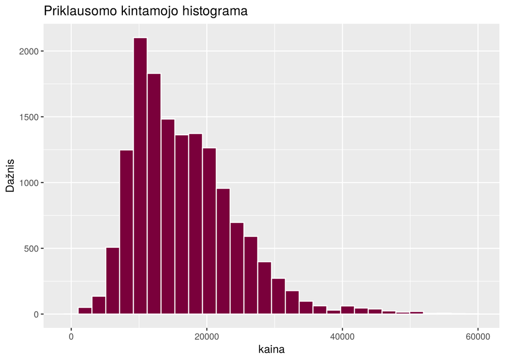

```r
ggplot(duom, aes(x = price)) +
  geom_histogram(bins = 30, fill = "#7A003B", color = "white") +
  labs(title = "Priklausomo kintamojo histograma", x = "kaina", y = "Dažnis")
```

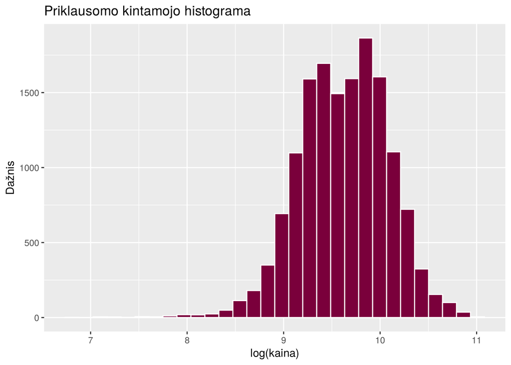

```r
ggplot(duom, aes(x = lkaina)) +
  geom_histogram(bins = 30, fill = "#7A003B", color = "white") +
  labs(title = "Priklausomo kintamojo histograma", x = "log(kaina)", y = "Dažnis")
```

```r
set.seed(2026)
shapiro.test(sample(duom$lkaina, 5000))   # shapiro.test leidžia iki 5000 stebėjimų – atsitiktinė imtis
```

```
##
##  Shapiro-Wilk normality test
##
## data:  sample(duom$lkaina, 5000)
## W = 0.98587, p-value < 2.2e-16
```

Kaina (£) turi ilgą dešinę uodegą, todėl modeliuojamas jos logaritmas – log(kainos) histograma beveik simetriška. (Shapiro–Wilk W = 0,986; didelėje imtyje testas atmeta normalumą ir dėl menkų nukrypimų, todėl remiamės histograma.)

# 3 Besąlyginis modelis ir ICC

Besąlyginis modelis sudaromas centruotiems duomenims (lkaina_c = lkaina − vidurkis), kaip siūloma paskaitoje – tada hipotezė apie γ00 turi prasmę. Automobilio lygmuo: lkaina_c = β0 + e; modelio lygmuo: β0 = γ00 + u0; jungtinis modelis: lkaina_c = γ00 + u0 + e.

```r
model.0 <- lme(lkaina_c ~ 1, random = ~ 1 | model, data = duom)   # REML
summary(model.0)
```

```
## Linear mixed-effects model fit by REML
##   Data: duom
##        AIC      BIC    logLik
##   9206.619 9229.439 -4600.309
##
## Random effects:
##  Formula: ~1 | model
##         (Intercept)  Residual
## StdDev:   0.4512149 0.3282657
##
## Fixed effects:  lkaina_c ~ 1
##                 Value Std.Error    DF  t-value p-value
## (Intercept) 0.1319131 0.0986444 14843 1.337259  0.1812
##
## Standardized Within-Group Residuals:
##         Min          Q1         Med          Q3         Max
## -7.62122370 -0.54790905  0.02654351  0.64888580  3.10461270
##
## Number of Observations: 14864
## Number of Groups: 21
```

```r
VarCorr(model.0)
```

```
## model = pdLogChol(1)
##             Variance  StdDev
## (Intercept) 0.2035949 0.4512149
## Residual    0.1077583 0.3282657
```

```r
tau00 <- as.numeric(VarCorr(model.0)[1, "Variance"])
sigma2_0 <- model.0$sigma^2
ICC <- tau00 / (tau00 + sigma2_0)
ICC
```

```
## [1] 0.6539033
```

```r
intervals(model.0)    # PI dispersijų st. nuokrypiams (ar tau00 > 0, sigma^2 > 0)
```

```
## Approximate 95% confidence intervals
##
##  Fixed effects:
##                   lower      est.     upper
## (Intercept) -0.06144212 0.1319131 0.3252684
##
##  Random Effects:
##   Level: model
##                     lower      est.    upper
## sd((Intercept)) 0.3302999 0.4512149 0.616394
##
##  Within-group standard error:
##     lower      est.     upper
## 0.3245526 0.3282657 0.3320212
```

Iš `summary(model.0)`: γ̂00 = 0,132 (centruotos log(kainos) modelių vidurkis), StdDev (Intercept) = 0,4512, Residual = 0,3283, todėl τ̂00 ≈ 0,4512² ≈ 0,2036, σ̂² ≈ 0,3283² ≈ 0,1078.

H0: γ00 = 0 neatmetama (p = 0,181) – centruotų duomenų modelių vidurkis statistiškai reikšmingai nesiskiria nuo bendro vidurkio. H0: τ00 = 0 ir H0: σ² = 0 atmetamos (`intervals()` st. nuokrypių 95 % PI 0,330–0,617 ir 0,325–0,332 neapima nulio), t. y. τ00 > 0 ir σ² > 0.

**ICC = 0,2036 / (0,2036 + 0,1078) = 0,654** ≥ 0,10 – apie 65 % log(kainos) skirtumų priklauso nuo automobilio modelio, todėl hierarchinė struktūra būtina.

# 4 Intervalinių I lygmens kintamųjų koreliacijos

```r
round(cor(duom[, c("amzius", "rida", "mpg")]), 3)
```

```
##        amzius  rida   mpg
## amzius  1.000 0.763 0.397
## rida    0.763 1.000 0.404
## mpg     0.397 0.404 1.000
```

Stipriausiai koreliuoja amžius ir rida (r = 0,763): senesni automobiliai daugiau nuvažiavę. Koreliacija mažesnė už 0,8, todėl abu kintamieji paliekami. mpg su kitais koreliuoja vidutiniškai (≈ 0,40).

# 5 Dviejų lygmenų modelis

- 1 lygio (automobilio) kintamieji: amzius, rida, mpg (intervaliniai), transmission, fuelType (kategoriniai; R sukuria pseudokintamuosius Manual, SemiAuto, Petrol, bazinės kategorijos – Automatic, Diesel)
- 2 lygio (modelio) kintamasis: vid_variklis
- Automobilio lygmuo: lkaina = β0 + β1·amzius + β2·rida + β3·mpg + β4·Manual + β5·SemiAuto + β6·Petrol + e
- Modelio lygmuo: β0 = γ00 + γ01·vid_variklis + u0; β1 = γ10 + u1; β2 = γ20; β3 = γ30; β4 = γ40; β5 = γ50; β6 = γ60
- Jungtinis modelis: lkaina = [γ00 + γ01·vid_variklis + γ10·amzius + γ20·rida + γ30·mpg + γ40·Manual + γ50·SemiAuto + γ60·Petrol] + [u0 + u1·amzius + e]
- Fiksuoto poveikio kintamieji: vid_variklis, amzius, rida, mpg, Manual, SemiAuto, Petrol; atsitiktinio poveikio kintamasis: amzius.

```r
ctrl <- lmeControl(opt = "optim", maxIter = 200, msMaxIter = 200)
model.1 <- lme(lkaina ~ 1 + vid_variklis + amzius + rida + mpg + transmission + fuelType,
               random = ~ 1 + amzius | model, data = duom, control = ctrl)   # REML
summary(model.1)        # fiksuoti parametrai (Fixed effects) ir st. nuokrypiai (Random effects)
```

```
## Linear mixed-effects model fit by REML
##   Data: duom
##         AIC       BIC   logLik
##   -16476.69 -16385.41 8250.344
##
## Random effects:
##  Formula: ~1 + amzius | model
##  Structure: General positive-definite, Log-Cholesky parametrization
##             StdDev     Corr
## (Intercept) 0.17479458 (Intr)
## amzius      0.02510045 -0.2
## Residual    0.13767222
##
## Fixed effects:  lkaina ~ 1 + vid_variklis + amzius + rida + mpg + transmission +      fuelType
##                           Value  Std.Error    DF   t-value p-value
## (Intercept)            9.951270 0.15837281 14837  62.83446  0.0000
## vid_variklis           0.361404 0.08340239    19   4.33326  0.0004
## amzius                -0.092262 0.00585691 14837 -15.75261  0.0000
## rida                  -0.004567 0.00009152 14837 -49.90354  0.0000
## mpg                   -0.008298 0.00020024 14837 -41.44091  0.0000
## transmissionManual    -0.111400 0.00399957 14837 -27.85312  0.0000
## transmissionSemi-Auto  0.011970 0.00406983 14837   2.94118  0.0033
## fuelTypePetrol        -0.077700 0.00380680 14837 -20.41092  0.0000
##  Correlation:
##                       (Intr) vd_vrk amzius rida   mpg    trnsmM trnS-A
## vid_variklis          -0.968
## amzius                -0.045 -0.006
## rida                   0.012 -0.006 -0.110
## mpg                   -0.097  0.037 -0.022 -0.133
## transmissionManual    -0.005  0.007 -0.003 -0.024 -0.272
## transmissionSemi-Auto -0.020  0.007  0.002 -0.003 -0.038  0.709
## fuelTypePetrol        -0.082  0.039 -0.030  0.051  0.621 -0.155 -0.030
##
## Standardized Within-Group Residuals:
##          Min           Q1          Med           Q3          Max
## -13.41379730  -0.63565241  -0.05194186   0.62157632   6.90274778
##
## Number of Observations: 14864
## Number of Groups: 21
```

```r
VarCorr(model.1)        # dispersijos: tau00, tau11, sigma^2
```

```
## model = pdLogChol(1 + amzius)
##             Variance     StdDev     Corr
## (Intercept) 0.0305531458 0.17479458 (Intr)
## amzius      0.0006300326 0.02510045 -0.2
## Residual    0.0189536404 0.13767222
```

```r
model.0ml <- update(model.0, method = "ML")   # modelių palyginimui – ML įverčiai
model.1ml <- update(model.1, method = "ML")

# Ar reikalingas atsitiktinis amžiaus nuolydis?
model.1a <- lme(lkaina ~ 1 + vid_variklis + amzius + rida + mpg + transmission + fuelType,
                random = ~ 1 | model, data = duom, method = "ML", control = ctrl)
anova(model.1ml, model.1a)
```

```
##           Model df       AIC       BIC   logLik   Test  L.Ratio p-value
## model.1ml     1 12 -16554.14 -16462.86 8289.071
## model.1a      2 10 -15901.27 -15825.21 7960.637 1 vs 2 656.8689  <.0001
```

```r
AIC(model.0ml)
```

```
## [1] 9203.8
```

```r
AIC(model.1ml)
```

```
## [1] -16554.14
```

Iš *Fixed effects* (Value): γ̂00 = 9,951; γ̂01 = 0,361; γ̂10 = −0,0923; γ̂20 = −0,00457; γ̂30 = −0,00830; γ̂40 = −0,111; γ̂50 = 0,0120; γ̂60 = −0,0777 – visi statistiškai reikšmingi (p < 0,05). Iš *Random effects* (StdDev²): τ̂00 = 0,1748² = 0,0306; τ̂11 = 0,0251² = 0,00063; σ̂² = 0,1377² = 0,0190.

Be atsitiktinio amžiaus nuolydžio AIC padidėja nuo −16 554,14 iki −15 901,27, L.Ratio = 656,87, p < 0,0001 – nuolydis u1 reikalingas.

# 6 Modelis su sąveika 1

β1 = γ10 + γ11·vid_variklis + u1 – ar didesnio variklio modeliai nuvertėja greičiau?

```r
model.2ml <- update(model.1ml, . ~ . + vid_variklis:amzius)
summary(model.2ml)$tTable
```

```
##                              Value    Std.Error    DF    t-value       p-value
## (Intercept)            9.914485968 0.1530479507 14836  64.780260  0.000000e+00
## vid_variklis           0.381839978 0.0807136740    19   4.730797  1.454581e-04
## amzius                -0.066060520 0.0223376200 14836  -2.957366  3.107685e-03
## rida                  -0.004565207 0.0000915456 14836 -49.868118  0.000000e+00
## mpg                   -0.008300338 0.0002002250 14836 -41.455044  0.000000e+00
## transmissionManual    -0.111370958 0.0039999865 14836 -27.842833 2.402838e-166
## transmissionSemi-Auto  0.011973986 0.0040702153 14836   2.941856  3.267562e-03
## fuelTypePetrol        -0.077714644 0.0038066624 14836 -20.415428  2.188669e-91
## vid_variklis:amzius   -0.014403994 0.0118311184 14836  -1.217467  2.234460e-01
```

```r
anova(model.1ml, model.2ml)
```

```
##           Model df       AIC       BIC   logLik   Test  L.Ratio p-value
## model.1ml     1 12 -16554.14 -16462.86 8289.071
## model.2ml     2 13 -16553.56 -16454.67 8289.781 1 vs 2 1.419155  0.2335
```

Sąveikos koeficientas γ̂11 = −0,0144, p = 0,223 – nereikšmingas; AIC beveik nepasikeitė (−16 554,14 → −16 553,56), L.Ratio = 1,42, p = 0,234. Modeliai statistiškai reikšmingai nesiskiria, todėl ši sąveika nereikalinga.

# 7 Modelis su sąveika 2

β2 = γ20 + γ21·vid_variklis – ar didesnio variklio modeliams rida kainą veikia kitaip?

```r
model.3ml <- update(model.1ml, . ~ . + vid_variklis:rida)
summary(model.3ml)$tTable
```

```
##                               Value    Std.Error    DF    t-value       p-value
## (Intercept)            9.9592589569 0.1509483215 14836  65.977938  0.000000e+00
## vid_variklis           0.3572534267 0.0794495548    19   4.496607  2.470796e-04
## amzius                -0.0929325311 0.0058304665 14836 -15.939124  1.002303e-56
## rida                  -0.0051526274 0.0004412139 14836 -11.678298  2.257307e-31
## mpg                   -0.0083039367 0.0002002579 14836 -41.466206  0.000000e+00
## transmissionManual    -0.1114088836 0.0039997218 14836 -27.854158 1.779895e-166
## transmissionSemi-Auto  0.0118285151 0.0040713146 14836   2.905331  3.674073e-03
## fuelTypePetrol        -0.0777183173 0.0038067724 14836 -20.415803  2.172394e-91
## vid_variklis:rida      0.0003513233 0.0002590348 14836   1.356278  1.750312e-01
```

```r
anova(model.1ml, model.3ml)
```

```
##           Model df       AIC       BIC   logLik   Test  L.Ratio p-value
## model.1ml     1 12 -16554.14 -16462.86 8289.071
## model.3ml     2 13 -16553.97 -16455.08 8289.985 1 vs 2 1.828025  0.1764
```

Sąveikos koeficientas γ̂21 = 0,00035, p = 0,175 – nereikšmingas; AIC nesumažėjo (−16 554,14 → −16 553,97), L.Ratio = 1,83, p = 0,176. Modeliai statistiškai reikšmingai nesiskiria, todėl ši sąveika nereikalinga.

Abu modeliai su sąveikomis turėjo nereikšmingus sąveikų koeficientus, todėl **galutiniu modeliu renkamės dviejų lygmenų modelį be sąveikų (model.1).**

# 8 Galutinis modelis

```r
summary(model.1)     # galutinis modelis (be sąveikos), REML įverčiai
```

```
## Linear mixed-effects model fit by REML
##   Data: duom
##         AIC       BIC   logLik
##   -16476.69 -16385.41 8250.344
##
## Random effects:
##  Formula: ~1 + amzius | model
##  Structure: General positive-definite, Log-Cholesky parametrization
##             StdDev     Corr
## (Intercept) 0.17479458 (Intr)
## amzius      0.02510045 -0.2
## Residual    0.13767222
##
## Fixed effects:  lkaina ~ 1 + vid_variklis + amzius + rida + mpg + transmission +      fuelType
##                           Value  Std.Error    DF   t-value p-value
## (Intercept)            9.951270 0.15837281 14837  62.83446  0.0000
## vid_variklis           0.361404 0.08340239    19   4.33326  0.0004
## amzius                -0.092262 0.00585691 14837 -15.75261  0.0000
## rida                  -0.004567 0.00009152 14837 -49.90354  0.0000
## mpg                   -0.008298 0.00020024 14837 -41.44091  0.0000
## transmissionManual    -0.111400 0.00399957 14837 -27.85312  0.0000
## transmissionSemi-Auto  0.011970 0.00406983 14837   2.94118  0.0033
## fuelTypePetrol        -0.077700 0.00380680 14837 -20.41092  0.0000
##  Correlation:
##                       (Intr) vd_vrk amzius rida   mpg    trnsmM trnS-A
## vid_variklis          -0.968
## amzius                -0.045 -0.006
## rida                   0.012 -0.006 -0.110
## mpg                   -0.097  0.037 -0.022 -0.133
## transmissionManual    -0.005  0.007 -0.003 -0.024 -0.272
## transmissionSemi-Auto -0.020  0.007  0.002 -0.003 -0.038  0.709
## fuelTypePetrol        -0.082  0.039 -0.030  0.051  0.621 -0.155 -0.030
##
## Standardized Within-Group Residuals:
##          Min           Q1          Med           Q3          Max
## -13.41379730  -0.63565241  -0.05194186   0.62157632   6.90274778
##
## Number of Observations: 14864
## Number of Groups: 21
```

```r
VarCorr(model.1)
```

```
## model = pdLogChol(1 + amzius)
##             Variance     StdDev     Corr
## (Intercept) 0.0305531458 0.17479458 (Intr)
## amzius      0.0006300326 0.02510045 -0.2
## Residual    0.0189536404 0.13767222
```

```r
sigma2_1 <- model.1$sigma^2
(sigma2_0 - sigma2_1) / sigma2_0   # I lygmens dispersijos sąlyginis pokytis
```

```
## [1] 0.8241098
```

```r
AIC(model.0ml, model.1ml)
```

```
##           df       AIC
## model.0ml  3   9203.80
## model.1ml 12 -16554.14
```

Iš *Fixed effects* (Value): γ̂00 = 9,951; γ̂01 = 0,361; γ̂10 = −0,0923; γ̂20 = −0,00457; γ̂30 = −0,00830; γ̂40 = −0,111; γ̂50 = 0,0120; γ̂60 = −0,0777 – visi statistiškai reikšmingi (p < 0,05). Iš *Random effects* (StdDev²): τ̂00 = 0,1748² = 0,0306; τ̂11 = 0,0251² = 0,00063; corr(u0, u1) = −0,20; σ̂² = 0,1377² = 0,0190.

**Jungtinė lygtis su įverčiais:** lkaina = [9,951 + 0,361·vid_variklis − 0,0923·amzius − 0,00457·rida − 0,00830·mpg − 0,111·Manual + 0,0120·SemiAuto − 0,0777·Petrol] + [u0 + u1·amzius + e]

Kadangi Y = log(kaina), poveikis procentais = (e^koef − 1)·100: kiekvieni metai sumažina kainą apie 8,8 %, 1000 mylių ridos – apie 0,46 %, +1 mpg – apie 0,83 %. Mechaninė dėžė apie 10,5 % pigesnė, Semi-Auto apie 1,2 % brangesnė nei automatinė; benzininis automobilis apie 7,5 % pigesnis nei dyzelinis. Modelis su 1 l didesniu vidutiniu varikliu apie 44 % brangesnis. Amžiaus nuolydžio st. nuokrypis 0,025 – modeliai nuvertėja nevienodai (Caravelle ≈ 5,4 %, Beetle ≈ 13,2 % per metus).

**I lygmens dispersijos sąlyginis pokytis** = (0,1078 − 0,0190) / 0,1078 = **0,824**: lyginant su besąlyginiu modeliu, 82,4 % sumažėjo modeliu nepaaiškintų kainų skirtumų. **Akaikės indekso pokytis** (`AIC(model.0ml, model.1ml)`): 9 203,80 → −16 554,14, t. y. sumažėjo **25 758** vienetais (> 10) – galutinis modelis daug geresnis. (`anova()` čia netinka, nes besąlyginis modelis sudarytas centruotai priklausomai kintamajai, todėl lyginame AIC.)

# 9 Prielaidų tikrinimas

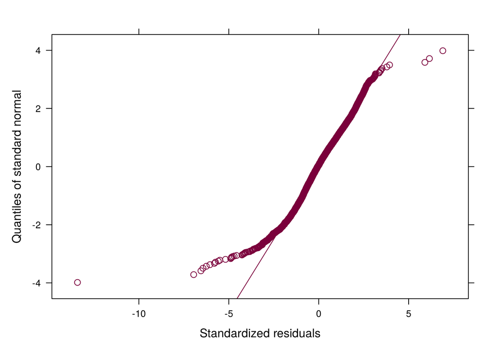

```r
qqnorm(model.1, ~ resid(., type = "p"), abline = c(0, 1), col = "#7A003B")      # I lygmens liekanos e
```

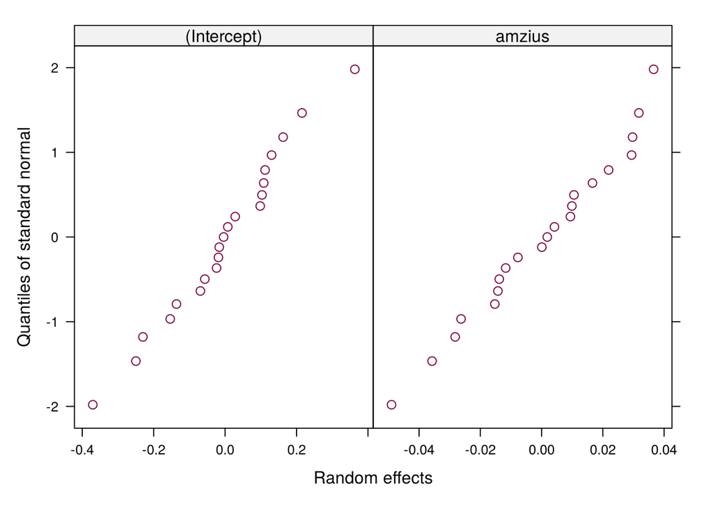

```r
qqnorm(model.1, ~ ranef(.), col = "#7A003B")      # II lygmens u0 ir u1
```

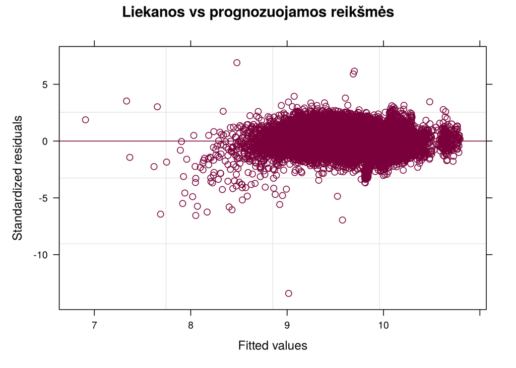

```r
plot(model.1, resid(., type = "pearson") ~ fitted(.), abline = 0, col = "#7A003B",
     main = "Liekanos vs prognozuojamos reikšmės")   # homoskedastiškumas
```

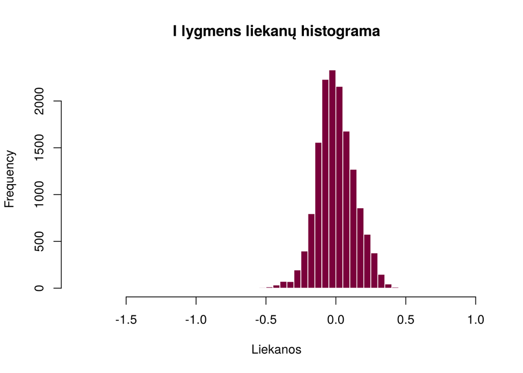

```r
hist(resid(model.1), breaks = 80, main = "I lygmens liekanų histograma", xlab = "Liekanos",
     col = "#7A003B", border = "white")
```

```r
mean(abs(resid(model.1, type = "pearson")) > 3)   # dalis liekanų, didesnių nei 3 st. nuokrypiai
```

```
## [1] 0.006189451
```

```r
round(ranef(model.1), 3)
```

```
##                 (Intercept) amzius
## Amarok               -0.136 -0.014
## Arteon                0.108 -0.015
## Beetle                0.162 -0.049
## Caddy Maxi Life      -0.230  0.032
## Caravelle             0.363  0.037
## CC                   -0.250  0.017
## Golf                  0.008  0.009
## Golf SV              -0.024 -0.008
## Jetta                -0.154 -0.026
## Passat               -0.004 -0.014
## Polo                 -0.057  0.002
## Scirocco             -0.069  0.004
## Sharan               -0.016  0.010
## Shuttle              -0.019  0.030
## T-Cross               0.130  0.011
## T-Roc                 0.098  0.029
## Tiguan                0.112 -0.012
## Tiguan Allspace       0.103  0.000
## Touareg               0.028 -0.036
## Touran                0.215 -0.028
## Up                   -0.370  0.022
```

# 10 Prognozė

```r
vv_golf <- unique(duom$vid_variklis[duom$model == "Golf"])
naujas_golf <- data.frame(model = factor("Golf", levels = levels(duom$model)),
                          vid_variklis = vv_golf, amzius = 3, rida = 30, mpg = 55,
                          transmission = factor("Manual", levels = levels(duom$transmission)),
                          fuelType = factor("Petrol", levels = levels(duom$fuelType)))
exp(predict(model.1, naujas_golf, level = 0))   # populiacijos lygis
```

```
## [1] 13318.66
## attr(,"label")
## [1] "Predicted values"
```

```r
exp(predict(model.1, naujas_golf, level = 1))   # su Golf atsitiktiniais efektais
```

```
##     Golf
## 13805.09
## attr(,"label")
## [1] "Predicted values"
```

3 metų benzininis Golf su mechanine dėže, nuvažiavęs 30 tūkst. mylių, su 55 mpg sąnaudomis, pagal fiksuotą dalį kainuotų apie **13 319 £**; įvertinus Golf atsitiktinius efektus – apie 13 805 £.

# 11 Išvados

- ICC = 0,654: apie 65 % kainų skirtumų lemia automobilio modelis, todėl HLM pagrįstas.
- Galutinis modelis – dviejų lygmenų modelis be sąveikų: kaina mažėja apie 8,8 % per metus, 0,46 % per 1000 mylių ir 0,83 % per 1 mpg; mechaninė dėžė ~10,5 % pigiau, benzinas ~7,5 % pigiau; modelis su 1 l didesniu vidutiniu varikliu ~44 % brangesnis.
- Galutinis modelis gerokai geresnis už besąlyginį: AIC sumažėjo 25 758, nepaaiškintų I lygmens skirtumų – 82,4 % mažiau.
- Kas nepavyko: abu modeliai su sąveikomis (vid_variklis·amzius ir vid_variklis·rida) turėjo nereikšmingus sąveikų koeficientus; didelėje imtyje statistiškai reikšmingi tampa ir maži efektai; liekanų kairė uodega; tai skelbimų, o ne sandorių kainos; tirta tik VW markė.